# NAIR: Network Analysis of Immune Repertoire

The `NAIR` package facilitates network analysis of the adaptive immune repertoire based on similarities among the receptor sequences. It implements custom pipelines developed in the following paper:

Hai Yang, Jason Cham, Zenghua Fan, Brian Neal, Tao He and Li Zhang. “Network Analysis of Immune Repertoire (NAIR) with Advanced Machine Learning Techniques.” In: Briefings in Bioinformatics (under review).

### What can `NAIR` do?

`NAIR` allows the user to:

- Perform general network analysis on immune repertoire sequence (RepSeq) data, including computing local and global network properties of nodes and clusters
- Search across multiple RepSeq samples for:
- Clones/clusters associated to a clinical outcome
- Public clones/clusters
- Generate customized visualizations of the immune repertoire network
- Perform further downstream analysis

### What data does `NAIR` support?

`NAIR` supports bulk and single-cell immune repertoire sequence data for T-cell or B-cell receptors (TCR or BCR).

- **Single-cell data:** Each row is a single T-cell/B-cell
- **Bulk data:** Each row is a distinct TCR/BCR clone (unique combination of V-D-J genes and nucleotide sequence) and typically includes a corresponding measurement of clonal abundance (e.g., clone count and clone frequency/fraction)

### How does `NAIR` model the immune repertoire as a network?

- Each TCR/BCR cell (single-cell data) or clone (bulk data) is modeled as a node (vertex) in the network
- For each node, we consider the corresponding receptor sequence (nucleotide or amino acid)
- For each pair of nodes, we measure the similarity in their receptor sequences (using the Hamming or Levenshtein distance)
- An edge is drawn between two nodes if the distance is below a specified threshold

# The `buildRepSeqNetwork()` function

General network analysis on RepSeq data is performed using the `buildRepSeqNetwork()` function. This function does the following:

- Builds the network graph for the immune repertoire
- Computes desired network properties
- Prints a customized `ggraph` plot of the network graph
- Returns meta-data for the TCR/BCR (nodes) in the network, including biological as well as network properties
- If desired for downstream analysis, can also return the network `igraph` and adjacency matrix, as well as the `ggraph` plot object

### Load Data

For demonstration purposes, we load a [public data set](https://www.10xgenomics.com/resources/datasets/pbm-cs-of-a-healthy-donor-v-1-1-1-standard-3-1-0) hosted at 10xgenomics.com using Bioconductor.

```r
if (!require("BiocFileCache", quietly = TRUE)) {
  if (!require("BiocManager", quietly = TRUE)) {
    install.packages("BiocManager")
  }
  BiocManager::install("BiocFileCache", update = FALSE)
}
library(NAIR)
library(BiocFileCache)
bfc <- BiocFileCache(ask = FALSE)
data_file <- bfcrpath(bfc, file.path(
  "http://cf.10xgenomics.com/samples/cell-vdj/3.1.0",
  "vdj_v1_hs_pbmc3/vdj_v1_hs_pbmc3_t_filtered_contig_annotations.csv"))
tcr_data <- read.csv(data_file, stringsAsFactors = FALSE)
head(tcr_data)
```

|  | barcode | is_cell | contig_id | high_confidence | length | chain | v_gene | d_gene | j_gene | c_gene | full_length | productive | cdr3 | cdr3_nt | reads | umis | raw_clonotype_id | raw_consensus_id |
| --- | --- | --- | --- | --- | --- | --- | --- | --- | --- | --- | --- | --- | --- | --- | --- | --- | --- | --- |
| 1 | AAACCTGAGATCTGAA-1 | True | AAACCTGAGATCTGAA-1_contig_1 | True | 521 | TRB | TRBV20-1 | None | TRBJ2-7 | TRBC2 | True | True | CSARDKGLSYEQYF | TGCAGTGCTAGAGACAAGGGGCTTAGCTACGAGCAGTACTTC | 9327 | 12 | clonotype100 | clonotype100_consensus_1 |
| 2 | AAACCTGAGATCTGAA-1 | True | AAACCTGAGATCTGAA-1_contig_2 | True | 474 | TRA | TRAV13-1 | None | TRAJ44 | TRAC | True | True | CAASIGPLGTGTASKLTF | TGTGCAGCAAGTATCGGCCCCCTAGGAACCGGCACTGCCAGTAAACTCACCTTT | 3440 | 3 | clonotype100 | clonotype100_consensus_2 |
| 3 | AAACCTGAGGAACTGC-1 | True | AAACCTGAGGAACTGC-1_contig_1 | True | 496 | TRB | TRBV7-2 | None | TRBJ2-1 | TRBC2 | True | True | CASSLGPSGEQFF | TGTGCCAGCAGCTTGGGACCATCGGGTGAGCAGTTCTTC | 32991 | 29 | clonotype101 | clonotype101_consensus_2 |
| 4 | AAACCTGAGGAACTGC-1 | True | AAACCTGAGGAACTGC-1_contig_2 | True | 505 | TRA | TRAV23/DV6 | None | TRAJ34 | TRAC | True | True | CAASDNTDKLIF | TGTGCAGCAAGCGATAACACCGACAAGCTCATCTTT | 10714 | 9 | clonotype101 | clonotype101_consensus_1 |
| 5 | AAACCTGAGGAGTCTG-1 | True | AAACCTGAGGAGTCTG-1_contig_1 | True | 495 | TRA | TRAV2 | None | TRAJ38 | TRAC | True | True | CAVEANNAGNNRKLIW | TGTGCTGTGGAGGCTAATAATGCTGGCAACAACCGTAAGCTGATTTGG | 1734 | 3 | clonotype102 | clonotype102_consensus_1 |
| 6 | AAACCTGAGGAGTCTG-1 | True | AAACCTGAGGAGTCTG-1_contig_2 | True | 526 | TRB | TRBV6-2 | None | TRBJ1-1 | TRBC1 | True | True | CASSRTGGTEAFF | TGTGCCAGCAGTCGGACAGGGGGCACTGAAGCTTTCTTT | 15530 | 13 | clonotype102 | clonotype102_consensus_2 |

```r
# load data sets
# dir_main <-
#   dirname(dirname(rstudioapi::getActiveDocumentContext()$path))
# dir_data <- file.path(dir_main, "input_data")
# dir_out <- file.path(dir_data, "dummy_output")
#
# data <- read.table(
#   file.path(dir_data, "TRB-Pt-10-2-500ng-15-04-2020-gDNA_S48.clones.txt"),
#   sep = '\t', header = TRUE)
```

Each row corresponds to a TCR sequence from a single cell, with the cell ID contained in the first column, `barcode`. Sequences from both the beta and alpha chains are present, as denoted by the values `TRA` and `TRB` in the column `chain`. We consider the beta-chain CDR3 amino acid sequences.

```r
# Subset rows for valid beta-chain CDR3 amino acid sequences
tcr_data <- tcr_data[tcr_data$chain == "TRB" & tcr_data$cdr3 != "None", ]

# Number of sequences/cells (rows)
nrow(tcr_data)
```

```
## [1] 4206
```

```r
head(tcr_data)
```

|  | barcode | is_cell | contig_id | high_confidence | length | chain | v_gene | d_gene | j_gene | c_gene | full_length | productive | cdr3 | cdr3_nt | reads | umis | raw_clonotype_id | raw_consensus_id |
| --- | --- | --- | --- | --- | --- | --- | --- | --- | --- | --- | --- | --- | --- | --- | --- | --- | --- | --- |
| 1 | AAACCTGAGATCTGAA-1 | True | AAACCTGAGATCTGAA-1_contig_1 | True | 521 | TRB | TRBV20-1 | None | TRBJ2-7 | TRBC2 | True | True | CSARDKGLSYEQYF | TGCAGTGCTAGAGACAAGGGGCTTAGCTACGAGCAGTACTTC | 9327 | 12 | clonotype100 | clonotype100_consensus_1 |
| 3 | AAACCTGAGGAACTGC-1 | True | AAACCTGAGGAACTGC-1_contig_1 | True | 496 | TRB | TRBV7-2 | None | TRBJ2-1 | TRBC2 | True | True | CASSLGPSGEQFF | TGTGCCAGCAGCTTGGGACCATCGGGTGAGCAGTTCTTC | 32991 | 29 | clonotype101 | clonotype101_consensus_2 |
| 6 | AAACCTGAGGAGTCTG-1 | True | AAACCTGAGGAGTCTG-1_contig_2 | True | 526 | TRB | TRBV6-2 | None | TRBJ1-1 | TRBC1 | True | True | CASSRTGGTEAFF | TGTGCCAGCAGTCGGACAGGGGGCACTGAAGCTTTCTTT | 15530 | 13 | clonotype102 | clonotype102_consensus_2 |
| 8 | AAACCTGAGGCTCTTA-1 | True | AAACCTGAGGCTCTTA-1_contig_2 | True | 525 | TRB | TRBV7-7 | None | TRBJ2-5 | TRBC2 | True | True | CASSLGRLVGRETQYF | TGTGCCAGCAGCTTAGGTCGCCTAGTCGGCCGAGAGACCCAGTACTTC | 10699 | 13 | clonotype103 | clonotype103_consensus_1 |
| 11 | AAACCTGTCAACGGGA-1 | True | AAACCTGTCAACGGGA-1_contig_2 | True | 466 | TRB | TRBV28 | None | TRBJ2-1 | TRBC2 | True | True | CASSLILRGEQFF | TGTGCCAGCAGTTTAATACTCAGGGGTGAGCAGTTCTTC | 15818 | 15 | clonotype104 | clonotype104_consensus_2 |
| 13 | AAACGGGAGACATAAC-1 | True | AAACGGGAGACATAAC-1_contig_1 | True | 478 | TRB | TRBV29-1 | None | TRBJ1-2 | TRBC1 | True | True | CSVEDRREGYGYTF | TGCAGCGTTGAAGACCGACGGGAGGGCTATGGCTACACCTTC | 9334 | 11 | clonotype105 | clonotype105_consensus_2 |

## Basic Usage

Calling `buildRepSeqNetwork()` for our example is as simple as executing the following line of code:

```r
buildRepSeqNetwork(tcr_data, "cdr3")
```

- The first argument specifies the data frame containing the rep-seq data, where each row corresponds to a single TCR/BCR clone (bulk data) or cell (single-cell data).
- The second argument specifies the column name or number of the data frame that contains the receptor sequences to be used as the basis of similarity between two cells or clones.

What does it do by default? Let’s observe the side effects and output when we call the function using the default settings:

```r
output <- buildRepSeqNetwork(tcr_data, "cdr3")
```

```
## Input data contains 4206 rows.
## Removing sequences with length less than 3... Done. 4206 rows remaining.
## Computing network edges based on a max hamming distance of 1... Done.
## 588 nodes in the network (after removing nodes with degree zero).
## Generating graph plot...
```

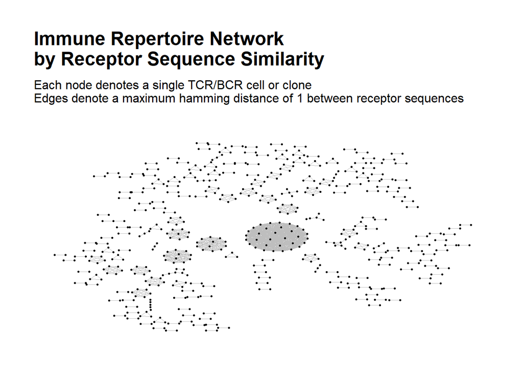

```
##  Done.
## Finished building network.
```

The console messages indicate the following tasks being performed:

- The input data is filtered to remove rows with sequences below 3 characters in length
- The edges of the network graph are computed by calculating the Hamming distance between pairs of the receptor sequences in `tcr_data$cdr3`
- Isolated nodes (those not joined by an edge to any other node) are removed from the graph
- A plot of the network graph is generated

We examine the output returned by the function.

```r
typeof(output)
```

```
## [1] "list"
```

```r
is.data.frame(output)
```

```
## [1] TRUE
```

```r
head(output)
```

|  | barcode | is_cell | contig_id | high_confidence | length | chain | v_gene | d_gene | j_gene | c_gene | full_length | productive | cdr3 | cdr3_nt | reads | umis | raw_clonotype_id | raw_consensus_id |
| --- | --- | --- | --- | --- | --- | --- | --- | --- | --- | --- | --- | --- | --- | --- | --- | --- | --- | --- |
| 27 | AAACGGGGTGTTCGAT-1 | True | AAACGGGGTGTTCGAT-1_contig_1 | True | 501 | TRB | TRBV7-8 | None | TRBJ1-1 | TRBC1 | True | True | CASSVDRNTEAFF | TGTGCCAGCAGCGTTGACAGGAACACTGAAGCTTTCTTT | 6821 | 9 | clonotype110 | clonotype110_consensus_1 |
| 30 | AAACGGGGTTAAAGAC-1 | True | AAACGGGGTTAAAGAC-1_contig_1 | True | 493 | TRB | TRBV9 | None | TRBJ1-1 | TRBC1 | True | True | CASKGETNTEAFF | TGTGCCAGCAAGGGGGAAACGAACACTGAAGCTTTCTTT | 6233 | 8 | clonotype32 | clonotype32_consensus_1 |
| 39 | AAAGATGAGTCACGCC-1 | True | AAAGATGAGTCACGCC-1_contig_1 | True | 494 | TRB | TRBV7-6 | None | TRBJ1-1 | TRBC1 | True | True | CASSVGQITEAFF | TGTGCCAGCAGCGTCGGACAGATCACTGAAGCTTTCTTT | 12734 | 14 | clonotype113 | clonotype113_consensus_2 |
| 61 | AAAGCAACAAACCCAT-1 | True | AAAGCAACAAACCCAT-1_contig_1 | True | 507 | TRB | TRBV14 | None | TRBJ2-4 | TRBC2 | True | True | CASSQASGGSKNIQYF | TGTGCCAGCAGCCAAGCTAGCGGCGGGTCCAAAAACATTCAGTACTTC | 8276 | 9 | clonotype120 | clonotype120_consensus_1 |
| 65 | AAAGCAAGTCCCTACT-1 | True | AAAGCAAGTCCCTACT-1_contig_2 | True | 559 | TRB | TRBV7-9 | None | TRBJ1-2 | TRBC1 | True | True | CASSPPGQGISATLNYGYTF | TGTGCCAGCAGTCCCCCGGGACAGGGGATTTCAGCTACCTTAAACTATGGCTACACCTTC | 11227 | 11 | clonotype33 | clonotype33_consensus_1 |
| 80 | AAAGTAGCATCCTTGC-1 | True | AAAGTAGCATCCTTGC-1_contig_2 | True | 510 | TRB | TRBV20-1 | None | TRBJ2-3 | TRBC2 | True | True | CSAYGTSGEVVQGLTQYF | TGCAGTGCTTACGGGACTAGCGGGGAAGTGGTTCAGGGCCTTACGCAGTATTTT | 12886 | 11 | clonotype18 | clonotype18_consensus_2 |

The returned data frame contains the same variables as the input data. Only rows corresponding to nodes that remain in the network graph are included (those corresponding to the dropped isolated nodes have been removed):

```r
nrow(output)
```

```
## [1] 588
```

Thus, this output data serves as biological meta-data for the nodes in the network graph, with each row corresponding to a node seen in the plot above.

## Network Properties

To include network properties in the output of `buildRepSeqNetwork()`, we use the `node_stats` and `cluster_stats` arguments; these respectively specify whether node-level and cluster-level properties are computed.

### Node-Level Network Properties

Use `node_stats = TRUE` to include node-level network properties.

```r
# Node-level properties
output <- buildRepSeqNetwork(tcr_data, "cdr3", node_stats = TRUE)
```

```
## Input data contains 4206 rows.
## Removing sequences with length less than 3... Done. 4206 rows remaining.
## Computing network edges based on a max hamming distance of 1... Done.
## 588 nodes in the network (after removing nodes with degree zero).
## Computing node-level network statistics... Done.
## Generating graph plot with nodes colored by degree...
```

```
##  Done.
## Finished building network.
```

```r
head(output)
```

|  | barcode | is_cell | contig_id | high_confidence | length | chain | v_gene | d_gene | j_gene | c_gene | full_length | productive | cdr3 | cdr3_nt | reads | umis | raw_clonotype_id | raw_consensus_id | degree | transitivity | eigen_centrality | centrality_by_eigen | betweenness | centrality_by_betweenness | authority_score | coreness | page_rank |
| --- | --- | --- | --- | --- | --- | --- | --- | --- | --- | --- | --- | --- | --- | --- | --- | --- | --- | --- | --- | --- | --- | --- | --- | --- | --- | --- | --- |
| 27 | AAACGGGGTGTTCGAT-1 | True | AAACGGGGTGTTCGAT-1_contig_1 | True | 501 | TRB | TRBV7-8 | None | TRBJ1-1 | TRBC1 | True | True | CASSVDRNTEAFF | TGTGCCAGCAGCGTTGACAGGAACACTGAAGCTTTCTTT | 6821 | 9 | clonotype110 | clonotype110_consensus_1 | 1 | NaN | 0.000000e+00 | 0 | 0 | 0 | 2.453269e-17 | 1 | 0.00170068 |
| 30 | AAACGGGGTTAAAGAC-1 | True | AAACGGGGTTAAAGAC-1_contig_1 | True | 493 | TRB | TRBV9 | None | TRBJ1-1 | TRBC1 | True | True | CASKGETNTEAFF | TGTGCCAGCAAGGGGGAAACGAACACTGAAGCTTTCTTT | 6233 | 8 | clonotype32 | clonotype32_consensus_1 | 4 | 1 | 1.962616e-17 | 0 | 0 | 0 | 9.813078e-17 | 4 | 0.00170068 |
| 39 | AAAGATGAGTCACGCC-1 | True | AAAGATGAGTCACGCC-1_contig_1 | True | 494 | TRB | TRBV7-6 | None | TRBJ1-1 | TRBC1 | True | True | CASSVGQITEAFF | TGTGCCAGCAGCGTCGGACAGATCACTGAAGCTTTCTTT | 12734 | 14 | clonotype113 | clonotype113_consensus_2 | 1 | NaN | 1.471962e-17 | 0 | 0 | 0 | 2.453269e-17 | 1 | 0.00170068 |
| 61 | AAAGCAACAAACCCAT-1 | True | AAAGCAACAAACCCAT-1_contig_1 | True | 507 | TRB | TRBV14 | None | TRBJ2-4 | TRBC2 | True | True | CASSQASGGSKNIQYF | TGTGCCAGCAGCCAAGCTAGCGGCGGGTCCAAAAACATTCAGTACTTC | 8276 | 9 | clonotype120 | clonotype120_consensus_1 | 1 | NaN | 9.813078e-18 | 0 | 0 | 0 | 2.453269e-17 | 1 | 0.00170068 |
| 65 | AAAGCAAGTCCCTACT-1 | True | AAAGCAAGTCCCTACT-1_contig_2 | True | 559 | TRB | TRBV7-9 | None | TRBJ1-2 | TRBC1 | True | True | CASSPPGQGISATLNYGYTF | TGTGCCAGCAGTCCCCCGGGACAGGGGATTTCAGCTACCTTAAACTATGGCTACACCTTC | 11227 | 11 | clonotype33 | clonotype33_consensus_1 | 1 | NaN | 9.813078e-18 | 0 | 0 | 0 | 2.453269e-17 | 1 | 0.00170068 |
| 80 | AAAGTAGCATCCTTGC-1 | True | AAAGTAGCATCCTTGC-1_contig_2 | True | 510 | TRB | TRBV20-1 | None | TRBJ2-3 | TRBC2 | True | True | CSAYGTSGEVVQGLTQYF | TGCAGTGCTTACGGGACTAGCGGGGAAGTGGTTCAGGGCCTTACGCAGTATTTT | 12886 | 11 | clonotype18 | clonotype18_consensus_2 | 2 | 1 | 0.000000e+00 | 0 | 0 | 0 | 6.869155e-17 | 2 | 0.00170068 |

The output data now contains node-level network properties in addition to the biological meta-data.

#### Choosing Node-Level Properties

To choose which node-level network properties are computed, use the `node_stat_settings()` function, passing its output to the `stats_to_include` argument of `buildRepSeqNetwork()`. The name of each node-level network property has a matching argument in `node_stat_settings()` that can be set to `TRUE` or `FALSE` to specify its inclusion. By default, calling `buildRepSeqNetwork()` with `node_stats = TRUE` uses the default values of `node_stat_settings()`, which are as follows:

```r
node_stat_settings()
```

```
## $degree
## [1] TRUE
##
## $cluster_id
## [1] FALSE
##
## $transitivity
## [1] TRUE
##
## $closeness
## [1] FALSE
##
## $centrality_by_closeness
## [1] FALSE
##
## $eigen_centrality
## [1] TRUE
##
## $centrality_by_eigen
## [1] TRUE
##
## $betweenness
## [1] TRUE
##
## $centrality_by_betweenness
## [1] TRUE
##
## $authority_score
## [1] TRUE
##
## $coreness
## [1] TRUE
##
## $page_rank
## [1] TRUE
##
## $all_stats
## [1] FALSE
```

See `?node_stat_settings()` for more details on the individual properties.

#### Include All Node-Level Properties

A convenient way to include all node-level network stats when calling `node_stat_settings()` is to simply use the argument `all_stats = TRUE`, which overrides the values of its other arguments.

When calling `buildRepSeqNetwork()` with `node_stats = TRUE`, a further shortcut to include all node-level network stats is simply to use `stats_to_include = "all"`.

### Cluster-Level Network Properties

We can include cluster-level network properties using `cluster_stats = TRUE`:

```r
# Node-level and cluster-level properties
output <- buildRepSeqNetwork(tcr_data, "cdr3", node_stats = TRUE,
                             cluster_stats = TRUE)
```

```
## Input data contains 4206 rows.
## Removing sequences with length less than 3... Done. 4206 rows remaining.
## Computing network edges based on a max hamming distance of 1... Done.
## 588 nodes in the network (after removing nodes with degree zero).
## Computing node-level network statistics... Done.
## Computing cluster membership within the network... Done.
## Computing statistics for the 212 clusters in the network... Done.
## Generating graph plot with nodes colored by degree...
```

```
##  Done.
## Finished building network.
```

The output is no longer a single data frame; instead, it is now a list which contains two data frames, one for the node-level meta data and one for the cluster-level meta data:

```r
# Output is a list
typeof(output)
```

```
## [1] "list"
```

```r
# Output is not a data frame
is.data.frame(output)
```

```
## [1] FALSE
```

```r
# Output list contains the following items:
names(output)
```

```
## [1] "node_data"     "cluster_stats"
```

```r
# View variables in the cluster-level meta data
head(output$cluster_stats)
```

|  | cluster_id | node_count | mean_seq_length | mean_degree | max_degree | seq_w_max_degree | agg_clone_count | max_clone_count | seq_w_max_count | diameter_length | assortativity | transitivity | edge_density | degree_centrality_index | closeness_centrality_index | eigen_centrality_index | eigen_centrality_eigenvalue |
| --- | --- | --- | --- | --- | --- | --- | --- | --- | --- | --- | --- | --- | --- | --- | --- | --- | --- |
| 1 | 1 | 32 | 16 | 31 | 31 | CASSLEVGGGEETQYF | NA | NA | NA | 2 | NaN | 1 | 1 | 0 | 0 | 1.184238e-16 | 31 |
| 2 | 2 | 12 | 19 | 11 | 11 | CASSEAPETSGTKGYEQFF | NA | NA | NA | 2 | NaN | 1 | 1 | 0 | 0 | 1.776357e-16 | 11 |
| 3 | 3 | 11 | 16 | 10 | 10 | CASSQLLGQGPYEQYF | NA | NA | NA | 2 | NaN | 1 | 1 | 0 | 0 | 0.000000e+00 | 10 |
| 4 | 4 | 8 | 17 | 7 | 7 | CASSQEASQEPYNEQFF | NA | NA | NA | 2 | NaN | 1 | 1 | 0 | 0 | 2.960595e-16 | 7 |
| 5 | 5 | 7 | 14 | 6 | 6 | CASMGATASYEQYF | NA | NA | NA | 2 | NaN | 1 | 1 | 0 | 0 | 1.776357e-16 | 6 |
| 6 | 6 | 6 | 15 | 5 | 5 | CASSQDSSSNSPLHF | NA | NA | NA | 2 | NaN | 1 | 1 | 0 | 0 | 2.220446e-16 | 5 |

Each row of the cluster-level meta data corresponds to a single cluster in the network.

Three of the cluster-level properties, `agg_clone_count`, `max_clone_count` and `seq_w_max_count`, were not computed, because they require us to specify the column name or number of our data containing measurements of clonal/cell abundance via the `count_col` argument. If the column name or number is supplied, these properties will be automatically computed along with the other cluster-level properties.

## Customized Visualization

The network graph plot produced by `buildRepSeqNetwork()` can be customized in various ways.

### Color nodes using meta data

The nodes in the graph can be colored according to node-level meta-data by specifying a variable name in the `color_nodes_by` argument. This can be a variable from the input data or one of the node-level network properties included in the output.

For example, we can color the nodes based on the `transitivity` network property:

```r
output <- buildRepSeqNetwork(tcr_data, "cdr3", node_stats = TRUE,
                             color_nodes_by = "transitivity")
```

```
## Input data contains 4206 rows.
## Removing sequences with length less than 3... Done. 4206 rows remaining.
## Computing network edges based on a max hamming distance of 1... Done.
## 588 nodes in the network (after removing nodes with degree zero).
## Computing node-level network statistics... Done.
## Generating graph plot with nodes colored by transitivity...
```

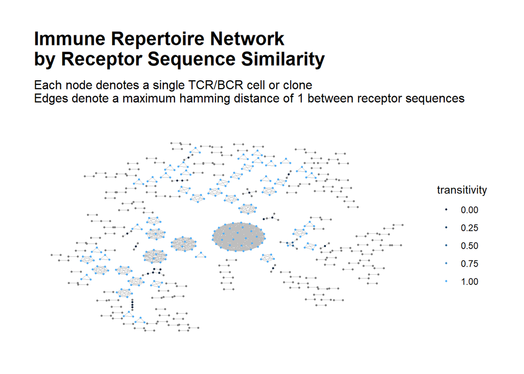

```
##  Done.
## Finished building network.
```

### Adjust node color palette

The color palette used to color the nodes can be specified using the `color_scheme` argument. Options include:

- `"default"` for default `ggplot2` colors
- A viridis color map option (e.g., `"viridis"`, `"plasma"`, etc., or one the corresponding strings “A” through “H”; see `?viridis` for details). The direction of the color gradient can be reversed by appending `"-1"`, as in `"viridis-1"`.
- A palette from `grDevices::hcl.pals()` (these can only be used if the variable used to color the nodes is discrete).

```r
# Using the "plasma" color scheme with reversed color gradient
output <- buildRepSeqNetwork(tcr_data, "cdr3",
                             node_stats = TRUE,
                             color_nodes_by = "transitivity",
                             color_scheme = "plasma-1")
```

```
## Input data contains 4206 rows.
## Removing sequences with length less than 3... Done. 4206 rows remaining.
## Computing network edges based on a max hamming distance of 1... Done.
## 588 nodes in the network (after removing nodes with degree zero).
## Computing node-level network statistics... Done.
## Generating graph plot with nodes colored by transitivity...
```

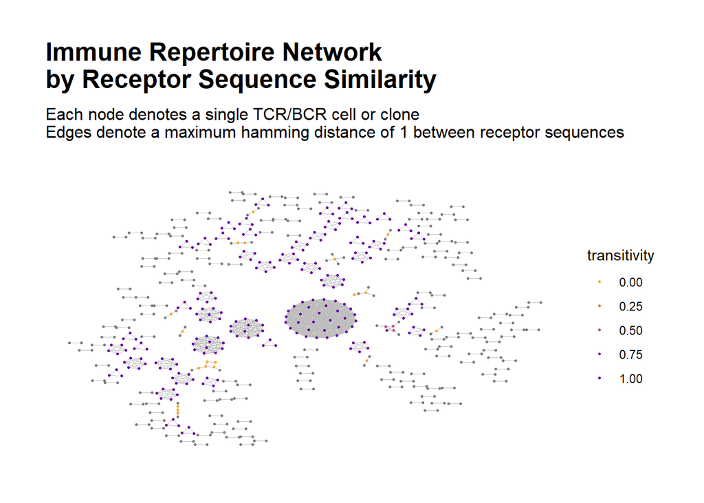

```
##  Done.
## Finished building network.
```

### Adjust node sizes or size nodes using meta data

The fixed size of the nodes (the default value is 0.5) can be adjusted by supplying a numeric value to the argument `size_nodes_by`:

```r
output <- buildRepSeqNetwork(tcr_data, "cdr3",
                             size_nodes_by = 1)
```

```
## Input data contains 4206 rows.
## Removing sequences with length less than 3... Done. 4206 rows remaining.
## Computing network edges based on a max hamming distance of 1... Done.
## 588 nodes in the network (after removing nodes with degree zero).
## Generating graph plot...
```

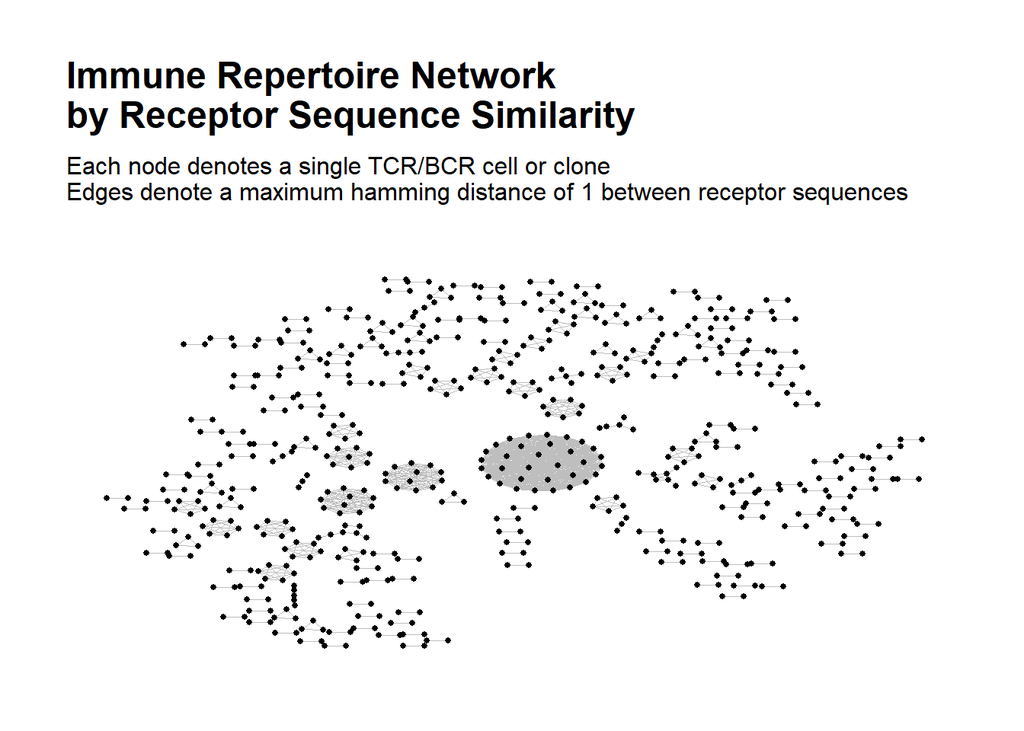

```
##  Done.
## Finished building network.
```

A value of `NULL` can also be used for the default `ggraph` node sizes.

The `size_nodes_by` argument also allows nodes to be sized dynamically based on node-level meta data by supplying a variable name, similarly to `color_nodes_by`.

When using dynamic node sizes, the minimum and maximum node sizes can be specified as a length-2 numeric vector to the `node_size_limits` argument. The default value of `NULL` uses the default range of node sizes in `ggraph`.

```r
# Size nodes dynamically by degree; use custom size range
output <- buildRepSeqNetwork(tcr_data, "cdr3",
                             node_stats = TRUE,
                             color_nodes_by = "transitivity",
                             size_nodes_by = "degree",
                             node_size_limits = c(0.5, 2))
```

```
## Input data contains 4206 rows.
## Removing sequences with length less than 3... Done. 4206 rows remaining.
## Computing network edges based on a max hamming distance of 1... Done.
## 588 nodes in the network (after removing nodes with degree zero).
## Computing node-level network statistics... Done.
## Generating graph plot with nodes colored by transitivity...
```

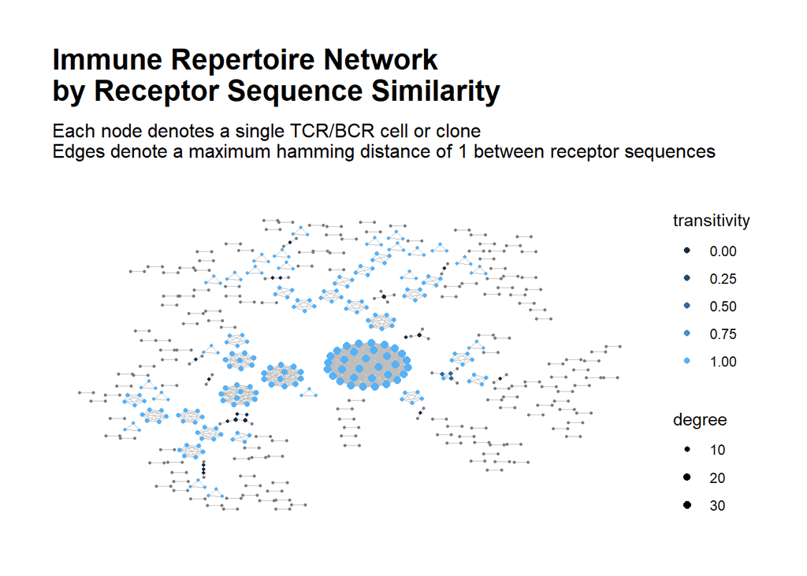

```
##  Done.
## Finished building network.
```

### Generate multiple graphs

It is possible to generate multiple plots, each using a different variable to color the nodes, as follows:

```r
output <- buildRepSeqNetwork(tcr_data, "cdr3",
                             node_stats = TRUE,
                             color_nodes_by = c("transitivity", "eigen_centrality"),
                             color_scheme = c("plasma-1", "default"),
                             size_nodes_by = "degree",
                             node_size_limits = c(0.5, 2))
```

```
## Input data contains 4206 rows.
## Removing sequences with length less than 3... Done. 4206 rows remaining.
## Computing network edges based on a max hamming distance of 1... Done.
## 588 nodes in the network (after removing nodes with degree zero).
## Computing node-level network statistics... Done.
## Generating graph plot with nodes colored by transitivity...
```

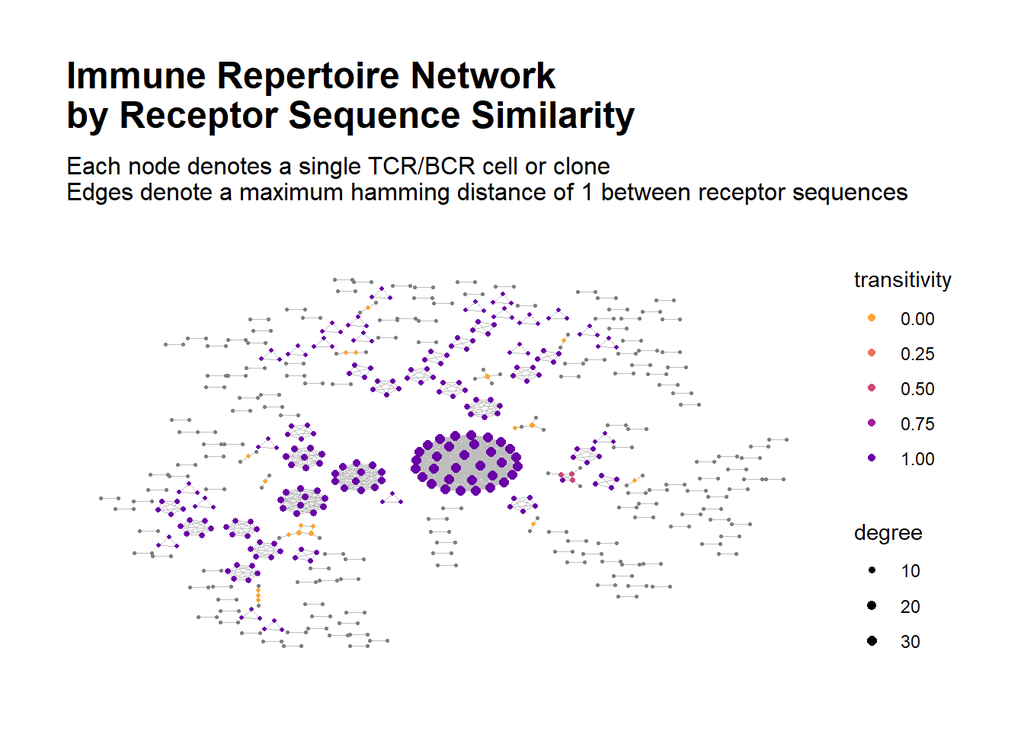

```
##  Done.
## Generating graph plot with nodes colored by eigen_centrality...
```

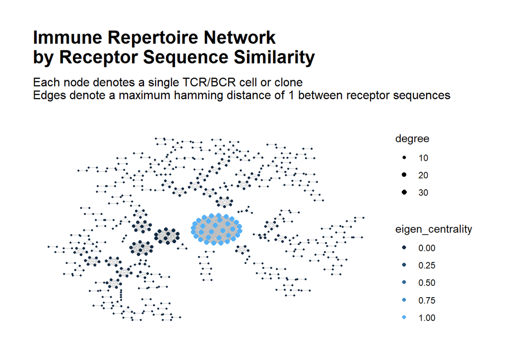

```
##  Done.
## Finished building network.
```

If a single value is supplied for `color_scheme`, it will be used for all of the plots.

### Plot title/subtitle

The plot title and subtitle can be specified using the `plot_title` and `plot_subtitle` arguments, or omitted by supplying a `NULL` value:

```
## Input data contains 4206 rows.
## Removing sequences with length less than 3... Done. 4206 rows remaining.
## Computing network edges based on a max hamming distance of 1... Done.
## 588 nodes in the network (after removing nodes with degree zero).
## Generating graph plot...
```

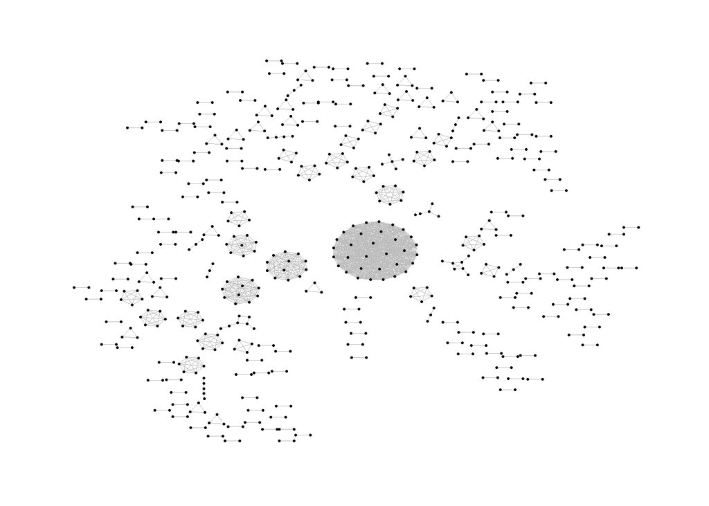

```
##  Done.
## Finished building network.
```

```r
output <- buildRepSeqNetwork(tcr_data, "cdr3",
                             plot_title = NULL,
                             plot_subtitle = NULL)
```

### Legends and legend titles

The legends for node color and size can be toggled using the logical arguments `color_legend` and `size_legend` (these are `TRUE` by default), while custom legend titles can be specified using the `color_title` and `size_title` arguments. Supplying a `NULL` value for a legend title will omit the legend title.

### Edge width

The thickness of the graph edges can be adjusted using the `edge_width` argument (the default value is 0.1).

### Further customization

The `ggraph` object for each plot generated by `buildRepSeqNetwork()` can be returned for downstream use with the argument `return_all = TRUE`. It can be manipulated using functions from the `ggplot2` package much like any plot created with the `ggplot` function. This provides the user total control to modify plots to their liking.

## Network Settings

Several arguments exist for customization of the settings used to build the network:

### Keep Isolated Nodes (Single-Node Clusters)

By default, any nodes in the network graph that do not share an edge with any other network node are removed, along with their corresponding rows in the data. There are typically many of these single, isolated nodes in a repertoire network; they are usually of little interest and their inclusion tends to clutter the visualization of the network graph.

However, sometimes it is desirable to keep all nodes in the network, including the isolated nodes. This can be done using the argument `drop_isolated_nodes = FALSE`.

### Distance Function

By default, similarity between TCR/BCR sequences is based on the Hamming distance, i.e., the number of non-matching characters in two sequences of equal length. When sequence lengths do not match, we effectively extend the shorter sequence, with the additional terms treated as non-matching with those of the longer sequence.

Our package also supports the Levenshtein (edit) distance, which measures the minimum number of single-character edits (insertions, deletions and transformations) required to transform one sequence into the other. It can be used in place of the Hamming distance with the argument `dist_type = "levenshtein"`. Here we use the Levenshtein distance to build a network based off of similarity in the CDR-3 nucleotide sequences.

```r
# Network based on Levenshtein distance
output <- buildRepSeqNetwork(tcr_data, "cdr3_nt", dist_type = "levenshtein")
```

```
## Input data contains 4206 rows.
## Removing sequences with length less than 3... Done. 4206 rows remaining.
## Computing network edges based on a max levenshtein distance of 1... Done.
## 407 nodes in the network (after removing nodes with degree zero).
## Generating graph plot...
```

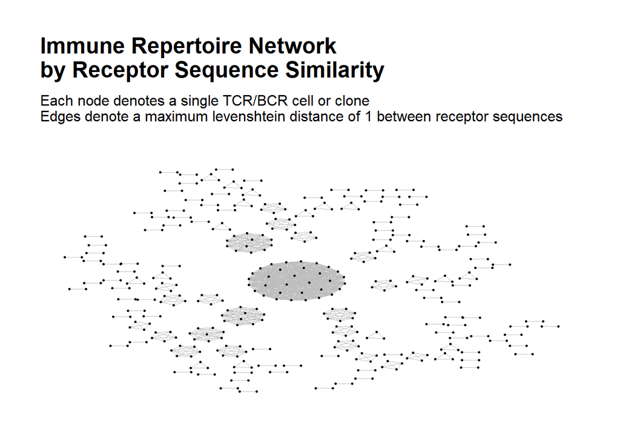

```
##  Done.
## Finished building network.
```

The Levenshtein distance innately applies to sequences of differing lengths and can correctly account for insertions and deletions, but is more computationally expensive, which could potentially pose challenges when working with very large data sets and using very long TCR/BCR sequences.

### Distance Cutoff

The distance function specified in the `dist_type` argument is used to model the similarity between TCR/BCR sequences. By default, two nodes in the network graph share an edge if their distance, as measured by this function, is at most 1. This cutoff value of 1 can be set to a different value, if desired, using the `dist_cutoff` argument.

## Other Arguments

### Input Filtering

- `min_seq_length` can be used to filter out TCR/BCR sequences by minimum length. Data rows with sequence lengths below this value will be dropped before computing the network graph. The default is 3.
- `drop_chars` can be used to filter out TCR/BCR sequences by content. It takes a character string or regular expression and checks each TCR/BCR sequence for a match; data rows with matches are dropped before computing the network graph.

### Only Keep Specific Columns of Input Data

By default, the node-level meta data returned by `buildRepSeqNetwork()` includes all columns of the input data. If you only wish for specific columns to be retained, specify these in a vector of column names or column numbers to the `other_cols` argument. Any relevant columns used by `buildRepSeqNetwork()`, such as the TCR/BCR sequence column specified by `seq_col`, as well as any columns specified in other arguments, such as `color_nodes_by`, will automatically be included.

### Output and Side Effects

- A complete set of intermediate and final outputs can be returned using `return_all = TRUE`. This can be useful for downstream analysis; see the `Downstream Analysis` section for more.
- Output can be saved to file by specifying a directory to the `output_dir` argument. By default, only a .csv file containing the node-level meta data and a .pdf file containing the network graph plot are saved. Use `save_all = TRUE` to save all output. The filenames used for each item can be changed from their default values using the arguments `data_outfile`, `plot_outfile`, `cluster_outfile`, `igraph_outfile` and `matrix_outfile`. The dimensions (in inches) for the pdf of the network graph plot can be adjusted using `plot_width` and `plot_height`, with the defaults being `12` and `10`.
- `print_plots = FALSE` can be used to prevent the plots from being printed to the `R` plotting window.

## Downstream Analysis

The output returned by `buildRepSeqNetwork()` can be used to facilitate further downstream analysis, particularly if invoked with `return_all = TRUE`. Doing so causes the function to return a list containing the following named components:

- `node_data`: A data frame containing the node-level biological and network meta data.
- `cluster_stats`: A data frame containing the cluster-level meta data (only included if `cluster_stats = TRUE`).
- `plots`: A list containing all plots generated, with each plot stored in as a separate list element named according to the variable used to color the nodes. Each plot is a `ggraph` object, which is a special kind of `ggplot` object.
- `adjacency_matrix`: The adjacency matrix for the network graph, stored as a sparse matrix of class `dgCMatrix` from the `Matrix` package.
- `igraph`: An object of the `igraph` class from the `igraph` package. This contains the list of nodes and edges for the network, and can be used to generate a `ggraph` plot using the `plotNetworkGraph` function.

### Downstream Customization of Plots

While the arguments of `buildRepSeqNetwork()` allow for substantial customization of the plots generated, you may occasionally find yourself wanting full control over all aspects of a plot. Or you may want to modify a plot further downstream based on the initial analysis.

When you use `return_all = TRUE`, all plots generated by `buildRepSeqNetwork()` are included in the output as `ggraph` objects. These are special kinds of `ggplot` objects, and their properties can be manipulated like any plot created with `ggplot()` using the same functions from the `ggplot2` package.

For example, suppose we have previously run the following:

```r
output <- buildRepSeqNetwork(tcr_data, "cdr3", node_stats = TRUE,
                             stats_to_include = "all",
                             return_all = TRUE)
```

```
## Input data contains 4206 rows.
## Removing sequences with length less than 3... Done. 4206 rows remaining.
## Computing network edges based on a max hamming distance of 1... Done.
## 588 nodes in the network (after removing nodes with degree zero).
## Computing cluster membership within the network... Done.
## Computing node-level network statistics... Done.
## Generating graph plot with nodes colored by degree...
```

```
##  Done.
## Finished building network.
```

Now, suppose we want to remove the plot title/subtitle, adjust the node size, color the nodes using the `umis` variable and change the color palette. We can do so using standard `ggplot2` functions (along with the `geom_node_point` function from the `ggraph` package) as follows:

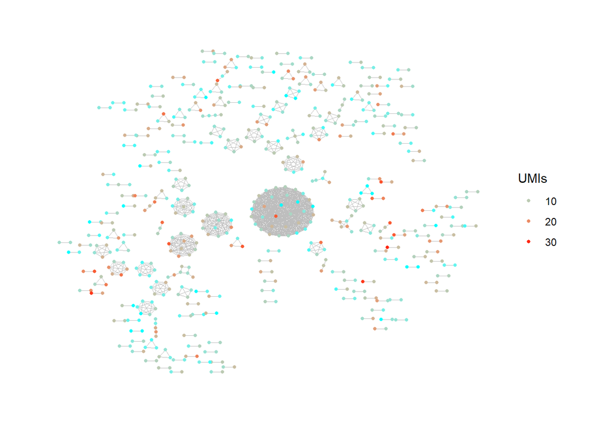

```r
library(ggplot2)
output$plots$degree + # modify plot from output
  labs(title = NULL, subtitle = NULL) +  # remove title/subtitle
  ggraph::geom_node_point(  # color nodes by coreness and set node size to 1
    aes(color = output$node_data$umis), size = 1) +
  guides(color = guide_legend(title = "UMIs")) + # change color legend title
  scale_color_gradient(low = "cyan", high = "red")  # change color gradient
```

### Generating New Plots

In addition to modifying plots returned by `buildRepSeqNetwork()`, we also can generate new ones from the `igraph` object included in its output. This can be simpler when you want a plot that is sufficiently different from the one in your existing output.

The `igraph` object can be passed to the `plotNetworkGraph` function in order to generate the plot; this function is a wrapper to the `ggraph` function, so a plot can also be generated directly using `ggraph()` for users experienced with `ggplot2`.

Here we generate a new plot, coloring the nodes using the `c_gene` variable, and manually specifying a color palette using the `scale_color_manual` function from the `ggplot2` package:

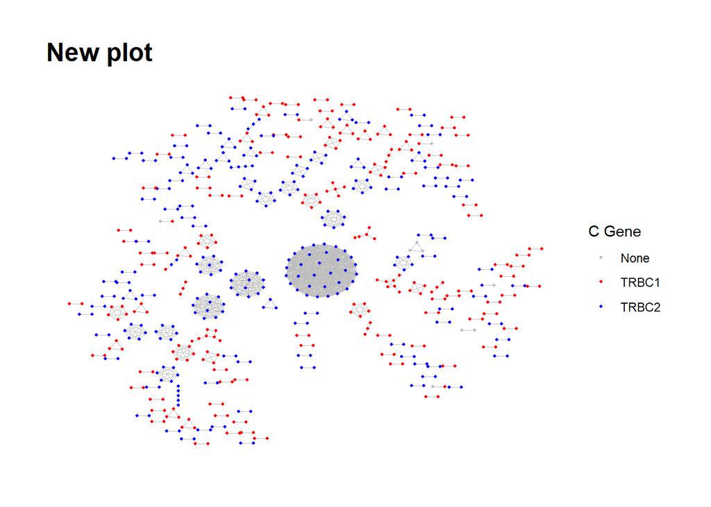

```r
plotNetworkGraph(network = output$igraph,
                 color_nodes_by = output$node_data$c_gene,
                 color_legend_title = "C Gene",
                 title = "New plot",
                 size_nodes_by = 0.8) +
  scale_color_manual(values = c("grey", "red", "blue"))
```

### Generating `igraph` Network From Adjacency Matrix

It is not necessary to save the `igraph` object for a network as long as one has the adjacency matrix returned by `buildRepSeqNetwork()`. Regenerating the `igraph` object from the adjacency matrix is extremely fast, and can be done using the `generateNetworkFromAdjacencyMat` function, which is a convenient wrapper to the `igraph` functions `graph_from_adjacency_matrix`, `simplify` and `as.undirected`.

```r
network <- generateNetworkFromAdjacencyMat(output$adjacency_matrix)
```

This object can then be passed to `plotNetworkGraph()` or other functions that act on `igraph` network objects.

### Generating `igraph` Network From TCR/BCR Sequences

If the adjacency matrix is unavailable and one wishes to regenerate the `igraph` network object directly from the TCR/BCR sequences without calling `buildRepSeqNetwork()` again, this can be done using the `generateNetworkFromSeqs` function. The column of the node-level meta data containing the TCR/BCR sequences is passed to the first argument:

```r
network <- generateNetworkFromSeqs(output$node_data$cdr3)
```

```
## Computing network edges based on a max hamming distance of 1... Done.
## 588 nodes in the network (after removing nodes with degree zero).
```

While this involves computing the adjacency matrix, it can be considerably faster than using `buildRepSeqNetwork()` again with the original input data: assuming `buildRepSeqNetwork()` was originally called with the default setting of `drop_isolated_nodes = TRUE`, then depending on the number of nodes dropped, the number of pairwise distances that must be recomputed could potentially be far less than the number originally computed.

### Computing Network Properties

Node-level network properties can be computed and added to the node-level meta data using the `igraph` network object:

```r
output <- buildRepSeqNetwork(tcr_data, "cdr3",
                             return_all = TRUE, print_plots = FALSE)
```

```
## Input data contains 4206 rows.
## Removing sequences with length less than 3... Done. 4206 rows remaining.
## Computing network edges based on a max hamming distance of 1... Done.
## 588 nodes in the network (after removing nodes with degree zero).
## Generating graph plot... Done.
## Finished building network.
```

```r
output$node_data <- addNodeNetworkStats(output$node_data,
                                        net = output$igraph,
                                        stats_to_include = "all")
```

```
## Computing cluster membership within the network... Done.
## Computing node-level network statistics... Done.
```

Cluster-level properties can be computed using the node-level meta data and the adjacency matrix:

```r
output$cluster_stats <-
  getClusterStats(data = output$node_data,
                  adjacency_matrix = output$adjacency_matrix,
                  seq_col = "cdr3")
```

```
## Computing cluster membership within the network... Done.
## Computing statistics for the 212 clusters in the network... Done.
```

### Computing Adjacency Matrices

If one wishes to regenerate the adjacency matrix for a network, this can be done by passing the column of the node-level meta data containing the TCR/BCR sequences to the `sparseAdjacencyMatFromSeqs` function. This function is also useful in general as a computationally fast and memory efficient tool for generating graph adjacency matrices based on the Hamming or Levenshtein distance, as the matrices are computed in C++ as sparse integer matrices and returned in `R` as sparse matrices of class `dgCMatrix` from the `Matrix` package.

```r
adjacency_matrix <- sparseAdjacencyMatFromSeqs(output$node_data$cdr3)
```

```
## Computing network edges based on a max hamming distance of 1... Done.
## 588 nodes in the network (after removing nodes with degree zero).
```